# Project 03

## Overview

Each of the five prompts below provide a question prompt that you need to address with one or more tables and/or plots. You only need to include text where explicitly asked for, however please include each graphic or output in its own code chunk. However you do need to properly label each plot (just a title is okay, but axes should have labels and color palettes should be chosen appropriately).

More detailed instructions are given on the Project 3 page linked to from the course website.

**Project Team**: Jeremy Mednik, Bryan Schnabel, Jackson McAtee

## Getting Started

Before running this notebook, select “Session > Restart R and Clear Output” in the menu above to start a new R session. This will clear any old data sets and give us a blank slate to start with.

After starting a new session, run the following code chunk to load the libraries and data that we will be working with today.

### Load the Data

There are three datasets that you will use in this project. They are similar to the datasets we had with the French data: a spatial object (county), a dataset of demographic data, and a dataset of daily Coronavirus records at the county level.

```r
county <- read_sf(file.path("data", "us_counties.geojson"))
covid <- read_csv(file.path("data", "us_county_covid.csv"))
demog <- read_csv(file.path("data", "us_county_metadata.csv"))
```

The COVID-19 dataset has fewer columns than the one from France. It has only cumulative case counts and reported deaths. Note that these are only the counties with complete data from 01 April 2020.

```r
covid
```

```
## # A tibble: 441,572 x 6
##    date       county   state fips  cases deaths
##    <date>     <chr>    <chr> <chr> <dbl>  <dbl>
##  1 2020-04-01 Autauga  AL    01001    10      0
##  2 2020-04-01 Baldwin  AL    01003    23      1
##  3 2020-04-01 Bibb     AL    01007     3      0
##  4 2020-04-01 Blount   AL    01009     5      0
##  5 2020-04-01 Bullock  AL    01011     3      0
##  6 2020-04-01 Butler   AL    01013     1      0
##  7 2020-04-01 Calhoun  AL    01015    11      0
##  8 2020-04-01 Chambers AL    01017    45      4
##  9 2020-04-01 Cherokee AL    01019     2      0
## 10 2020-04-01 Chilton  AL    01021    13      0
## # … with 441,562 more rows
```

The demographic data gives several points of information about each county. Unless otherwise noted, the data comes from 2019.

```r
demog
```

```
## # A tibble: 3,220 x 13
##    fips  state population pop_change_2018 unemployment_ra… median_hh_income
##    <chr> <chr>      <dbl>           <dbl>            <dbl>            <dbl>
##  1 01001 AL         55601             158              3.6            59338
##  2 01003 AL        218022            5403              3.6            57588
##  3 01005 AL         24881            -277              5.2            34382
##  4 01007 AL         22400            -155              4              46064
##  5 01009 AL         57840              13              3.5            50412
##  6 01011 AL         10138             -38              4.7            29267
##  7 01013 AL         19680            -218              4.8            37365
##  8 01015 AL        114277            -387              4.7            45400
##  9 01017 AL         33615            -143              3.9            39917
## 10 01019 AL         26032             217              3.6            42132
## # … with 3,210 more rows, and 7 more variables: pct_below_povert <dbl>,
## #   feb_temp_avg <dbl>, aug_temp_avg <dbl>, prc_bachelors <dbl>,
## #   physicians_per_pop <dbl>, per_dem_2016 <dbl>, per_gop_2016 <dbl>
```

Most of the variables should be self-explanatory. Unemployment rate is in percentages (0-100), median household income in USD. February and August average temperatures are in Celsius. The `physicians_per_pop` give the number of active physicians per 100k residents according to the AAMC in 2018 at the state level. Note that there is information for almost every county in the US, even if there are no records in the COVID-19 dataset.

## Prompts

### 1. Spatial Extent

**Question** Show a spatial visualization (i.e., a map) of the infection rate (cases per population) in the U.S. on 1 May 2020, 15 June 2020, and 1 October for the “lower 48” states (no Hawaii, Alaska, or Puerto Rico). Also, separately show the infection rate for Hawaii on 15 June 2020. Try to describe the patterns in a few short sentences. Make sure to use appropriate projections and color scales.

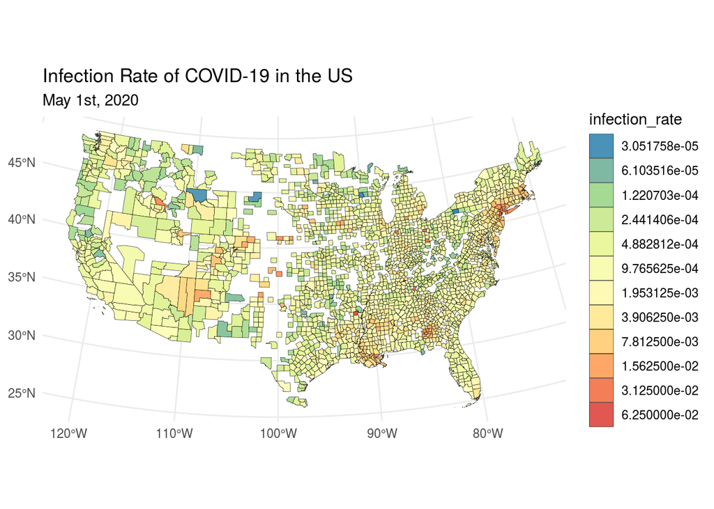

```r
county %>%
  inner_join(demog, by =c('fips','state')) %>%
  inner_join(covid, by =c('fips','state')) %>%
  filter(date == '2020-05-01') %>%
  filter(! state %in% c('HI','AK','PR')) %>%
  mutate(infection_rate = cases / population) %>%
  st_transform(3083) %>%
  ggplot() +
  geom_sf(aes(fill = infection_rate), color = "black", size = 0.1) +
  scale_fill_distiller(trans = "log2", palette = "Spectral", guide = "legend", n.breaks = 10) +
  labs(title = "Infection Rate of COVID-19 in the US", subtitle = "May 1st, 2020")
```

On May 1st, only a few areas in the U.S. have a high infection rate. New York City had a lot of Coronavirus cases, along with some areas in the south and the midwest.

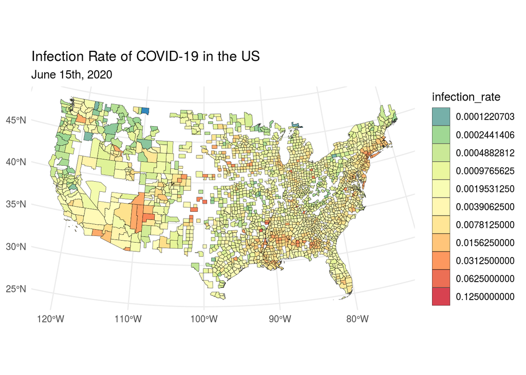

```r
county %>%
  inner_join(demog, by =c('fips','state')) %>%
  inner_join(covid, by =c('fips','state')) %>%
  filter(date == '2020-06-15') %>%
  filter(! state %in% c('HI','AK','PR')) %>%
  mutate(infection_rate = cases / population) %>%
  st_transform(3083) %>%
  ggplot() +
  geom_sf(aes(fill = infection_rate), color = "black", size = 0.1) +
  scale_fill_distiller(trans = "log2", palette = "Spectral", guide = "legend", n.breaks = 10) +
  labs(title = "Infection Rate of COVID-19 in the US", subtitle = "June 15th, 2020")
```

On June 15th, some counties that had a high infection rate in the south has spread to new counties. The Coronavirus cases have also spread further across the Northeast. Lastly, regions in Arizona and California have gotten worse and there are more emerging hotspots.

[figure not shown]

```r
county %>%
  inner_join(demog, by =c('fips','state')) %>%
  inner_join(covid, by =c('fips','state')) %>%
  filter(date == '2020-08-01') %>%
  filter(! state %in% c('HI','AK','PR')) %>%
  mutate(infection_rate = cases / population) %>%
  st_transform(3083) %>%
  ggplot() +
  geom_sf(aes(fill = infection_rate), color = "black", size = 0.1) +
  scale_fill_distiller(trans = "log2", palette = "Spectral", guide = "legend", n.breaks = 10) +
  labs(title = "Infection Rate of COVID-19 in the US", subtitle = "October 1st, 2020")
```

[figure not shown]

```r
county %>%
  inner_join(demog, by =c('fips','state')) %>%
  inner_join(covid, by =c('fips','state')) %>%
  filter(date == '2020-08-01') %>%
  filter(state == 'HI') %>%
  mutate(infection_rate = cases / population) %>%
  st_transform(26961) %>%
  ggplot() +
  geom_sf(aes(fill = infection_rate), color = "black", size = 0.1) +
  scale_fill_distiller(trans = "log2", palette = "Spectral", guide = "legend", n.breaks = 10) +
  labs(title = "Infection Rate of COVID-19 in Hawaii", subtitle = "June 15th, 2020")
```

### 2. Political Party

**Question** How does the general political affiliation at the county level relate to the observed case fatality rate (cases / deaths) and the overall infection rate (cases / population)? Answer the question on a month-by-month basis (i.e., compute the rates for each month separately, not cumulatively) and plot these showing the change over time.

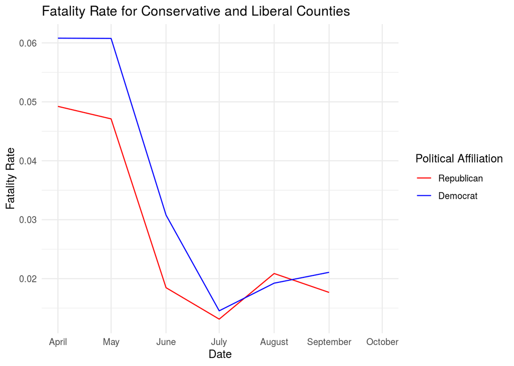

```r
demog %>%
 mutate(is_democrat = (per_dem_2016 > .5)) %>%
 inner_join(covid, by =c('fips','state')) %>%
 mutate(day = day(date)) %>%
 filter(day == 1) %>%
 group_by(is_democrat, date) %>%
 summarize(sm_sum(cases), sm_sum(population), sm_sum(deaths)) %>%
 mutate(new_deaths = lead(deaths_sum) - deaths_sum) %>%
 mutate(new_cases = lead(cases_sum) - cases_sum) %>%
 mutate(fatality_rate = new_deaths / new_cases) %>%
 mutate(infection_rate = new_cases / population_sum) %>%
 ggplot() +
 geom_line(aes(date, fatality_rate, color = is_democrat)) +
 scale_color_manual(labels = c("Republican", "Democrat"), values = c("red", "blue")) +
 scale_x_date(date_breaks = "month", date_minor_breaks = "month", date_labels = "%B") +
 labs(title = "Fatality Rate for Conservative and Liberal Counties", x = "Date", y = "Fatality Rate", color = "Political Affiliation")
```

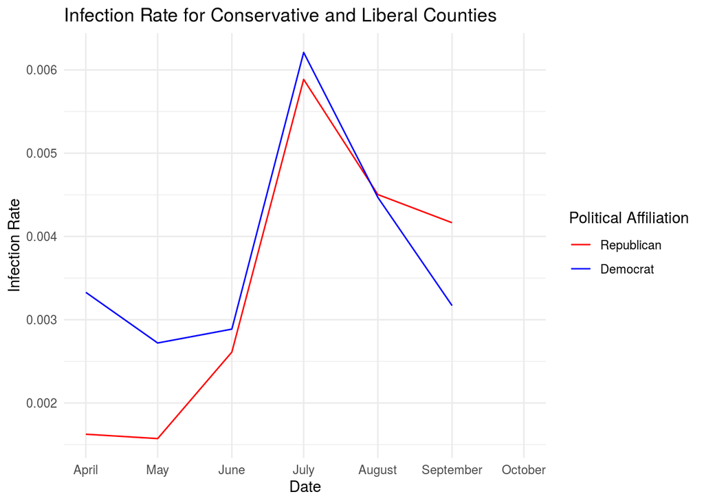

```r
demog %>%
 mutate(is_democrat = (per_dem_2016 > .5)) %>%
 inner_join(covid, by =c('fips','state')) %>%
 mutate(day = day(date)) %>%
 filter(day == 1) %>%
 group_by(is_democrat, date) %>%
 summarize(sm_sum(cases), sm_sum(population), sm_sum(deaths)) %>%
 mutate(new_deaths = lead(deaths_sum) - deaths_sum) %>%
 mutate(new_cases = lead(cases_sum) - cases_sum) %>%
 mutate(fatality_rate = new_deaths / new_cases) %>%
 mutate(infection_rate = new_cases / population_sum) %>%
 ggplot() +
 geom_line(aes(date, infection_rate, color = is_democrat)) +
 scale_color_manual(labels = c("Republican", "Democrat"), values = c("red", "blue")) +
 scale_x_date(date_breaks = "month", date_minor_breaks = "month", date_labels = "%B") +
 labs(title = "Infection Rate for Conservative and Liberal Counties", x = "Date", y = "Infection Rate", color = "Political Affiliation")
```

### 3. Largest Counties

**Question** Visualize the number of new cases in the 10 largest counties over the time range of the entire dataset for each day using a 7-day moving average.

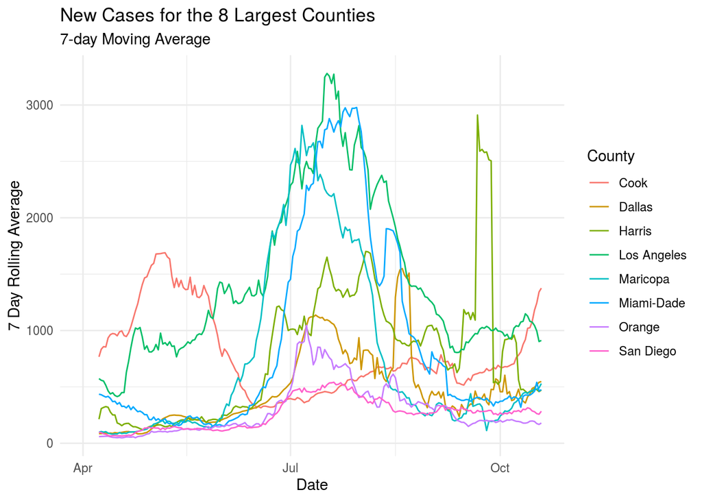

```r
covid %>%
  inner_join(demog, by= c('fips', 'state')) %>%
  arrange(desc(population)) %>%
  group_by(date) %>%
  slice(1:8) %>%
  group_by(county) %>%
  mutate(cases_new = cases - lag(cases)) %>%
  mutate(cases_new7 = roll_meanr(cases_new, n = 7)) %>%
  ggplot() +
  geom_line(aes(x = date, y = cases_new7, color = county)) +
  labs(title = "New Cases for the 8 Largest Counties", subtitle = "7-day Moving Average", x = "Date",
      y = "7 Day Rolling Average", color = "County")
```

### 4. Population Density

**Question** Compute the population density of each county. Group the counties into 5 groups based on their population density and compute the overall fatality rate (cases / deaths), infection rate (cases / population) and mortality rate (deaths / cases) for each group on 1 October.

```r
county %>%
  left_join(demog, by = c("fips", "state")) %>%
  mutate(area = as.numeric(set_units(st_area(geometry), "km^2"))) %>%
  mutate(density = population / area) %>%
  mutate(bucket = cut(log2(density + 1), breaks = 5, labels = FALSE)) %>%
  as_tibble() %>%
  inner_join(covid, by= c('fips', 'state')) %>%
  filter(date == '2020-10-01') %>%
  group_by(bucket) %>%
  summarize(sm_sum(cases), sm_sum(deaths), sm_sum(population)) %>%
  mutate(fatality_rate = deaths_sum / cases_sum) %>%
  mutate(infection_rate = cases_sum / population_sum) %>%
  mutate(mortality_rate = deaths_sum / population_sum)
```

```
## # A tibble: 5 x 7
##   bucket cases_sum deaths_sum population_sum fatality_rate infection_rate
##    <int>     <dbl>      <dbl>          <dbl>         <dbl>          <dbl>
## 1      1     93164       2443        4665902        0.0262         0.0200
## 2      2   1180177      24821       56164188        0.0210         0.0210
## 3      3   2624469      62418      127017031        0.0238         0.0207
## 4      4   2767806      83819      114212693        0.0303         0.0242
## 5      5    118072       5453        5068569        0.0462         0.0233
## # … with 1 more variable: mortality_rate <dbl>
```

### 5. Cases and Deaths Lag

**Question** At the county level, aggregated over each week, what’s the “lag” between deaths and cases? That is, if we look at the number of deaths in one week in the dataset is it most closely correlated with the number of cases in the week in question, one week before, two weeks before, three weeks before, or more? As an optional challenge, try to plot the relationship without resorting to manually copying the numbers (you might need a pivot function here).

```r
covid %>%
 filter(wday(date) == 1) %>%
 group_by(fips, state) %>%
 mutate(new_cases = cases - lag(cases),
        new_deaths = deaths - lag(deaths)
        ) %>%
 mutate(new_cases_lag_1 = lag(new_cases, 1),
        new_cases_lag_2 = lag(new_cases, 2),
        new_cases_lag_3 = lag(new_cases, 3),
        new_cases_lag_4 = lag(new_cases, 4),
        new_cases_lag_5 = lag(new_cases, 5)
        ) %>%
 ungroup() %>%
 summarize(
   sm_cor(new_deaths, new_cases),
   sm_cor(new_deaths, new_cases_lag_1),
   sm_cor(new_deaths, new_cases_lag_2),
   sm_cor(new_deaths, new_cases_lag_3),
   sm_cor(new_deaths, new_cases_lag_4),
   sm_cor(new_deaths, new_cases_lag_5))
```

```
## # A tibble: 1 x 6
##   new_deaths_new_… new_deaths_new_… new_deaths_new_… new_deaths_new_…
##              <dbl>            <dbl>            <dbl>            <dbl>
## 1            0.659            0.701            0.735            0.753
## # … with 2 more variables: new_deaths_new_cases_lag_4_cor <dbl>,
## #   new_deaths_new_cases_lag_5_cor <dbl>
```

This dataset looks at the correlation values between the new cases and the new deaths for each week. By this graph, it can be seen that the lag between cases and deaths is between 3-4 weeks.

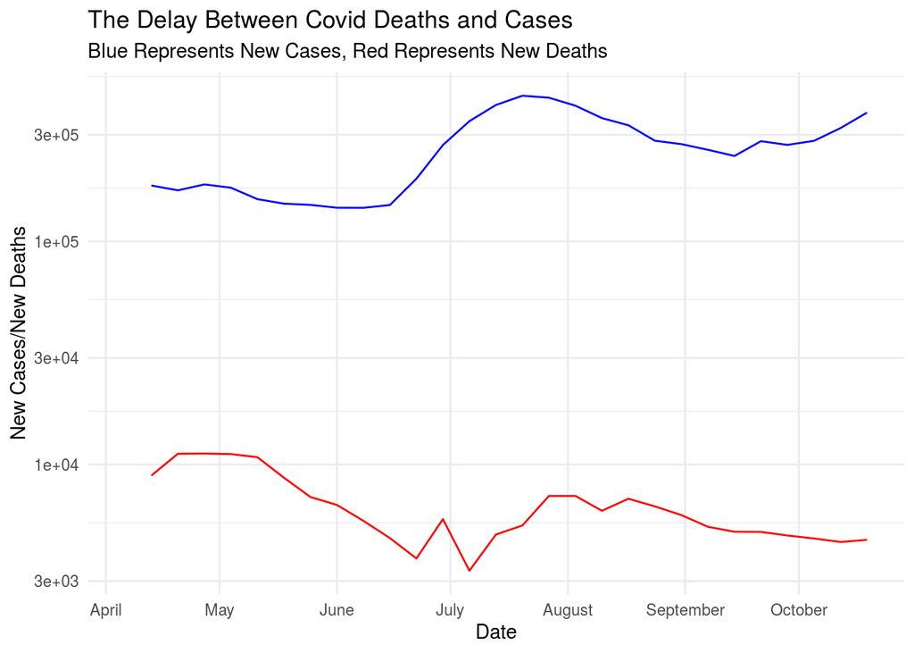

```r
covid %>%
  inner_join(demog, by = c('fips', 'state')) %>%
  mutate(wday = wday(date, label = TRUE, abbr = FALSE)) %>%
  filter(wday == "Monday") %>%
  group_by(date) %>%
  summarise(sm_sum(cases), sm_sum(deaths)) %>%
  mutate(new_cases = cases_sum- lag(cases_sum)) %>%
  mutate(new_deaths = deaths_sum - lag(deaths_sum)) %>%
  ggplot() +
    geom_line(aes(x = date, y= new_cases), color = "blue") +
    geom_line(aes(x = date, y = new_deaths), color = "red") +
    scale_y_log10() +
    scale_x_date(date_breaks = "month", date_labels = "%B", date_minor_breaks = "month") +
    labs(title = "The Delay Between Covid Deaths and Cases", subtitle = "Blue Represents New Cases, Red Represents New Deaths", x = "Date", y = "New Cases/New Deaths")
```